# Lab 7

02-11-2016

Data:

```r
load(url("http://www.openintro.org/stat/data/evals.RData"))
names(evals)
```

```
##  [1] "score"         "rank"          "ethnicity"     "gender"
##  [5] "language"      "age"           "cls_perc_eval" "cls_did_eval"
##  [9] "cls_students"  "cls_level"     "cls_profs"     "cls_credits"
## [13] "bty_f1lower"   "bty_f1upper"   "bty_f2upper"   "bty_m1lower"
## [17] "bty_m1upper"   "bty_m2upper"   "bty_avg"       "pic_outfit"
## [21] "pic_color"
```

These data come from an experiment.

1. True
2. False

answer: false

The original research question posed in the paper is whether beauty leads directly to the differences in course evaluations. Given the study design, should the question be rephrased? If so, how?

1. No, the question is worded accurately.
2. Yes, revise wording to “Is there an association between beauty and course evaluations?”
3. Yes, revise wording to “Does beauty score increase the professor’s course evaluations?”
4. Yes, revise wording to “Does beauty score decrease the professor’s course evaluations?”

Which of the following statements is false about the distribution of score?

answer: b

Which of the following statements is false about the distribution of score?

1. The median of the distribution is 4.3.
2. 25% of the students gave their professors a score of over 4.6.
3. 11 of students gave a professor a score below 3.
4. The left skewness of the data suggests that the students are less likely to rate the professors highly.

answer: D

```r
#Median of the data
median(evals$score)
```

```
## [1] 4.3
```

```r
#Summary of the Data
summary(evals$score)
```

```
##    Min. 1st Qu.  Median    Mean 3rd Qu.    Max.
##   2.300   3.800   4.300   4.175   4.600   5.000
```

```r
#number of students who gave proessor below 3
```

[output not shown]

Exercise: Excluding score, select two other variables and describe their relationship using an appropriate visualization (scatterplot, side-by-side boxplots, or mosaic plot).

Scatter plot

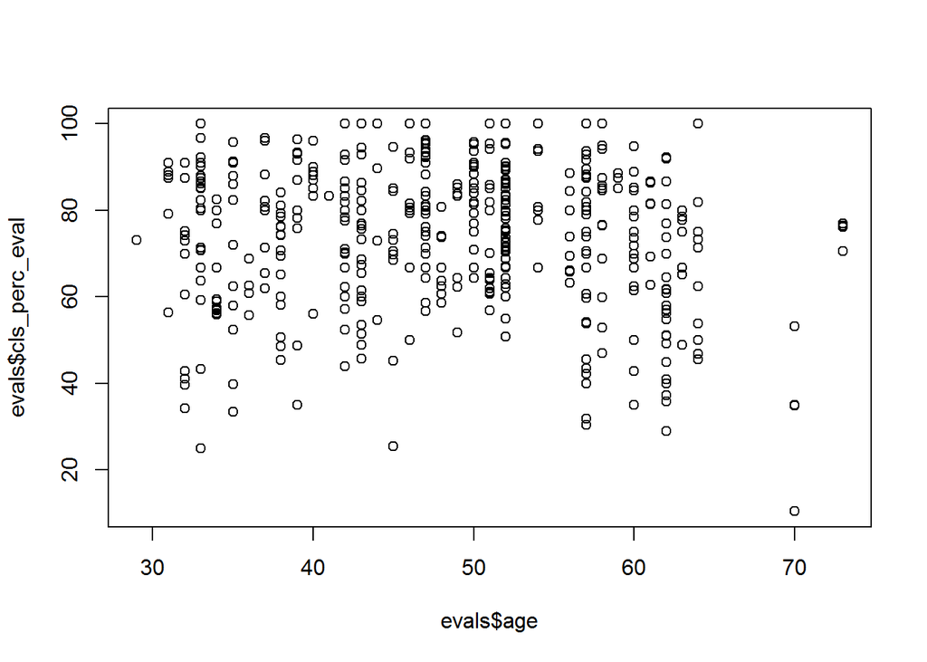

```r
plot(evals$age,evals$cls_perc_eval)
```

box plot

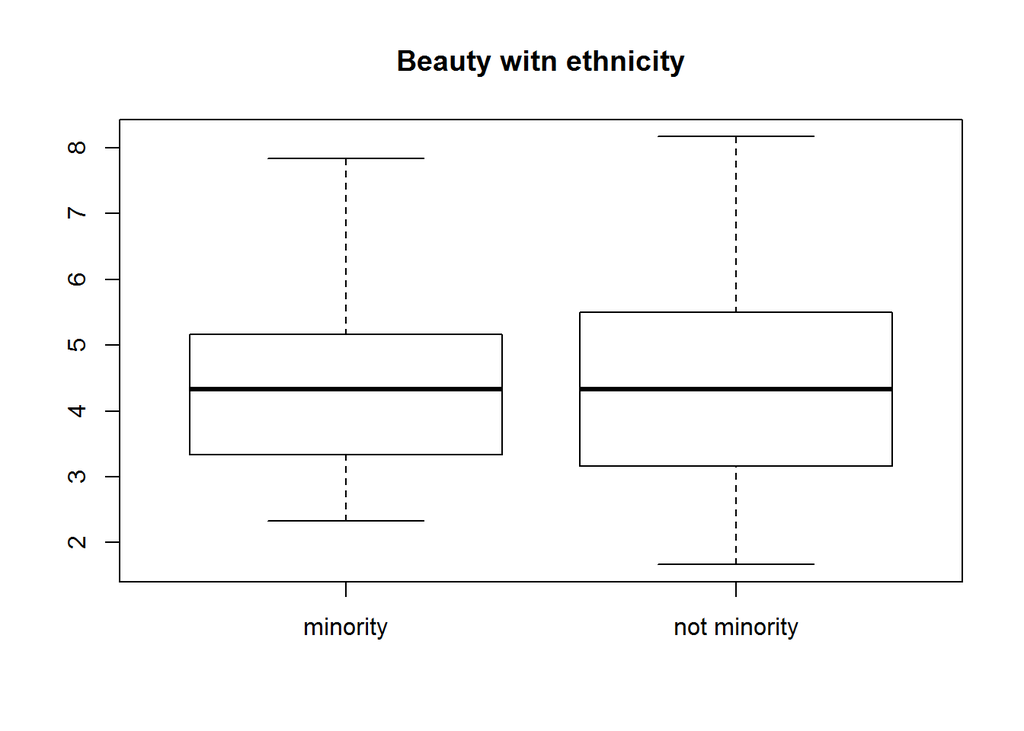

```r
boxplot(bty_avg~ethnicity, data = evals, main = "Beauty witn ethnicity")
```

Simple Linear Regression

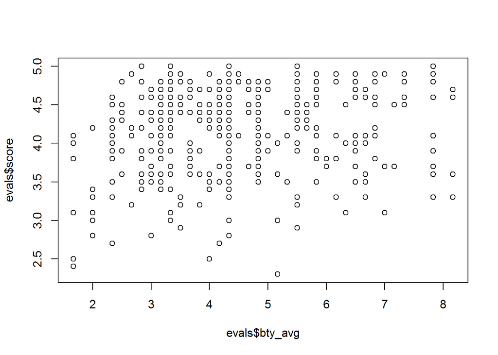

```r
plot(evals$score~evals$bty_avg)
```

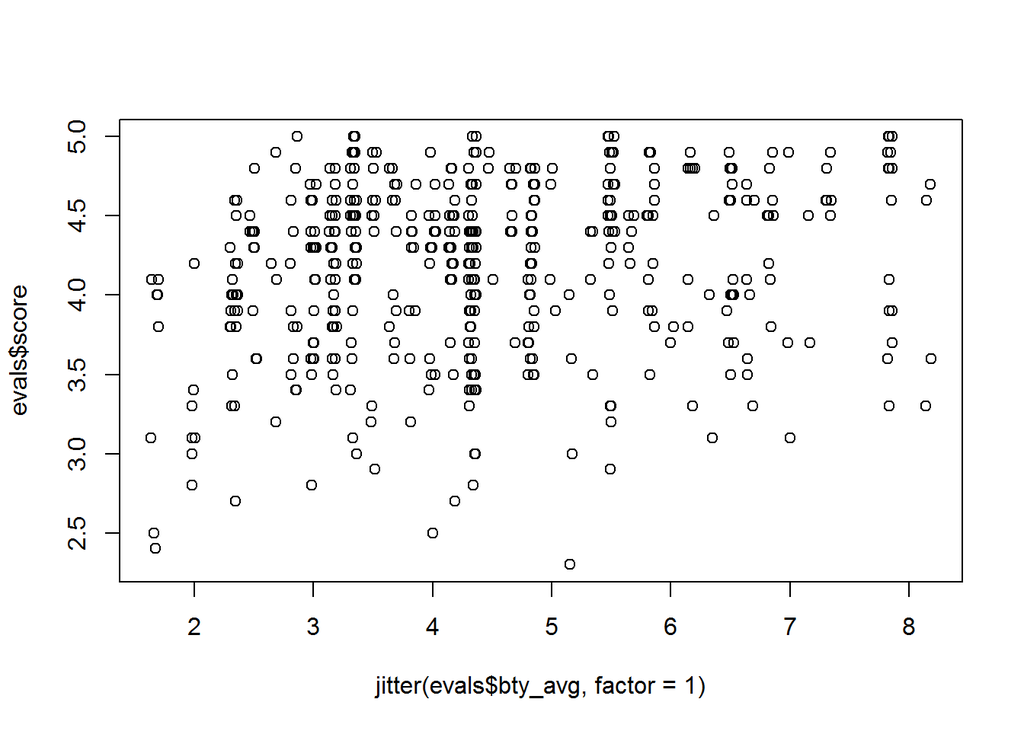

```r
plot(evals$score~jitter(evals$bty_avg, factor = 1))
```

```r
m_bty=lm(score~bty_avg, data = evals)
summary(m_bty)
```

```
##
## Call:
## lm(formula = score ~ bty_avg, data = evals)
##
## Residuals:
##     Min      1Q  Median      3Q     Max
## -1.9246 -0.3690  0.1420  0.3977  0.9309
##
## Coefficients:
##             Estimate Std. Error t value Pr(>|t|)
## (Intercept)  3.88034    0.07614   50.96  < 2e-16 ***
## bty_avg      0.06664    0.01629    4.09 5.08e-05 ***
## ---
## Signif. codes:  0 '***' 0.001 '**' 0.01 '*' 0.05 '.' 0.1 ' ' 1
##
## Residual standard error: 0.5348 on 461 degrees of freedom
## Multiple R-squared:  0.03502,    Adjusted R-squared:  0.03293
## F-statistic: 16.73 on 1 and 461 DF,  p-value: 5.083e-05
```

```r
anova(m_bty)
```

```
## Analysis of Variance Table
##
## Response: score
##            Df  Sum Sq Mean Sq F value    Pr(>F)
## bty_avg     1   4.786  4.7859  16.731 5.083e-05 ***
## Residuals 461 131.868  0.2860
## ---
## Signif. codes:  0 '***' 0.001 '**' 0.01 '*' 0.05 '.' 0.1 ' ' 1
```

```r
cor(evals$score,evals$bty_avg)
```

```
## [1] 0.1871424
```

Average beauty score seems to be a statistically and practically significant predictor.

1. True
2. False

answer: b

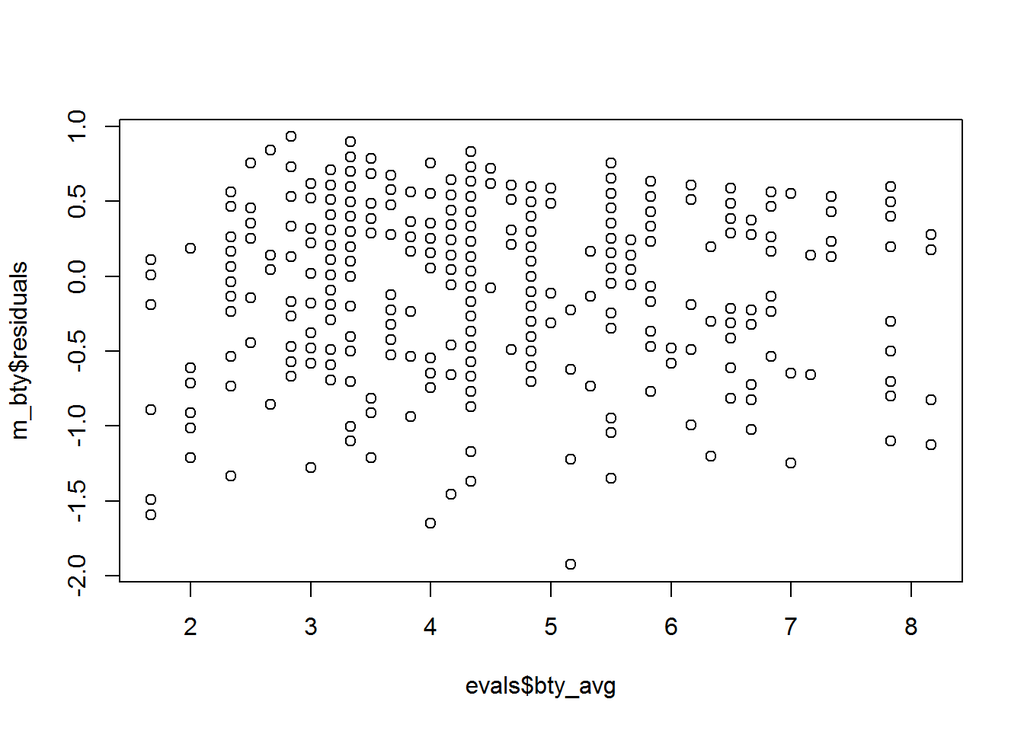

```r
plot(m_bty$residuals~evals$bty_avg)
```

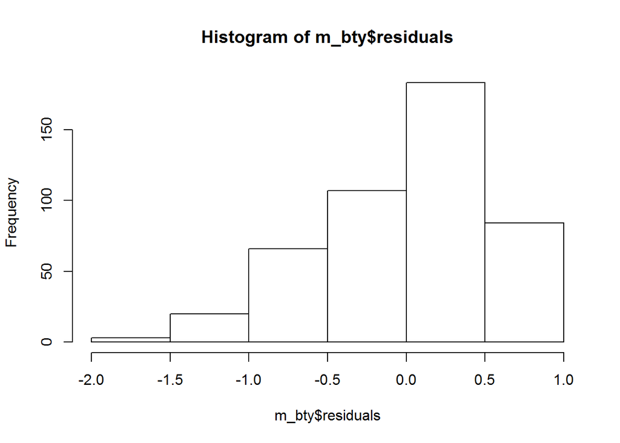

```r
hist(m_bty$residuals)
```

Use residual plots to evaluate whether the conditions of least squares regression are reasonable. Which of the following statements is an incorrect analysis of the residual plots and conditions?

1. Linear association: The residuals plot shows a random scatter.
2. Constant variance of residuals: No fan shape in residuals plot.
3. Nearly normal residuals: Residuals are right skewed, but the sample size is large, so this may not be an important violation of conditions.
4. Independent observations: Classes sampled randomly, no order effect.

answer: c

Multiple Regression

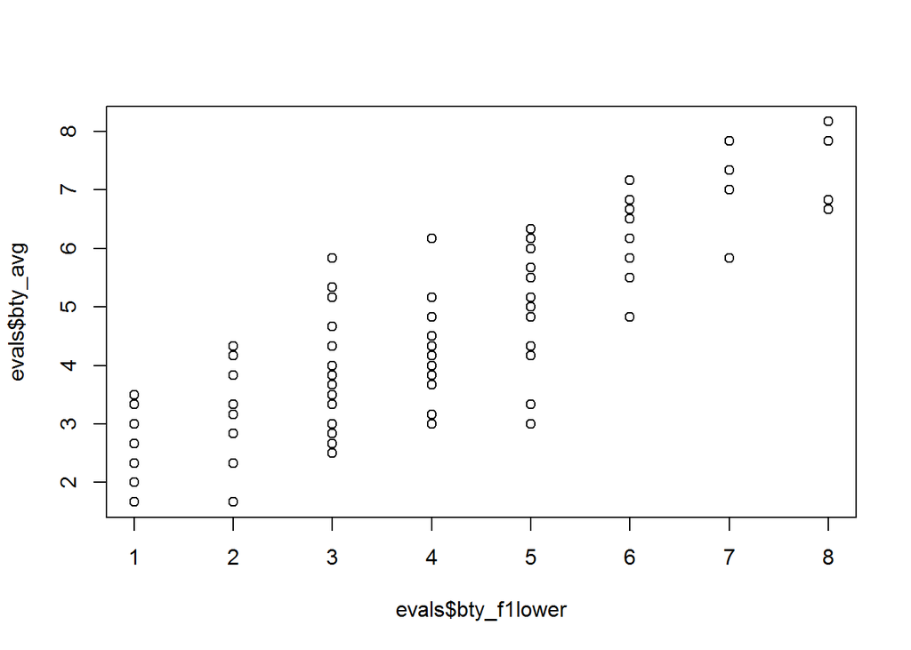

```r
plot(evals$bty_avg ~ evals$bty_f1lower)
```

```r
cor(evals$bty_avg,evals$bty_f1lower)
```

```
## [1] 0.8439112
```

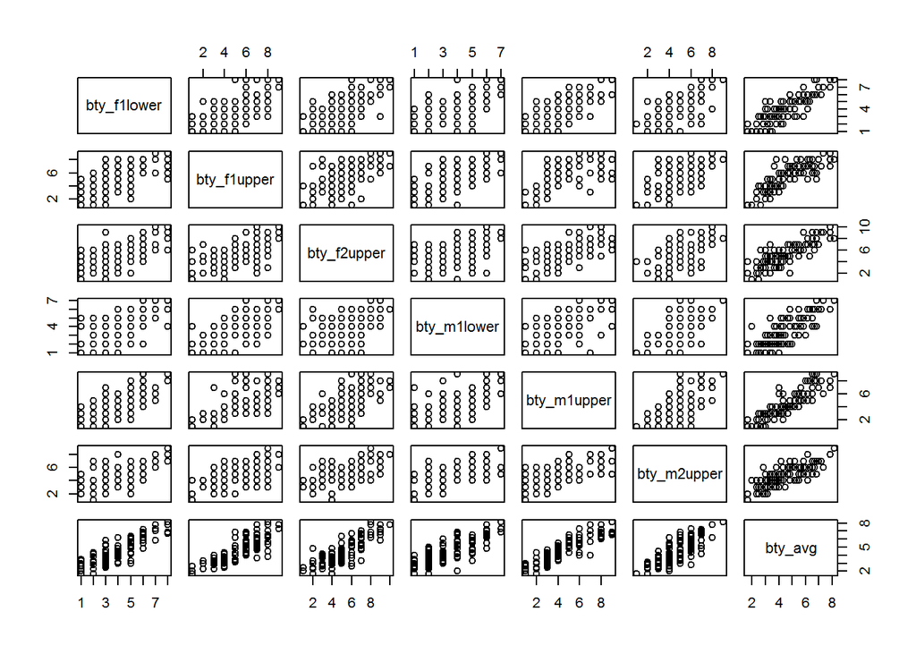

```r
plot(evals[,13:19])
```

```r
m_bty_gen<-lm(score~bty_avg+gender, data = evals)
summary(m_bty_gen)
```

```
##
## Call:
## lm(formula = score ~ bty_avg + gender, data = evals)
##
## Residuals:
##     Min      1Q  Median      3Q     Max
## -1.8305 -0.3625  0.1055  0.4213  0.9314
##
## Coefficients:
##             Estimate Std. Error t value Pr(>|t|)
## (Intercept)  3.74734    0.08466  44.266  < 2e-16 ***
## bty_avg      0.07416    0.01625   4.563 6.48e-06 ***
## gendermale   0.17239    0.05022   3.433 0.000652 ***
## ---
## Signif. codes:  0 '***' 0.001 '**' 0.01 '*' 0.05 '.' 0.1 ' ' 1
##
## Residual standard error: 0.5287 on 460 degrees of freedom
## Multiple R-squared:  0.05912,    Adjusted R-squared:  0.05503
## F-statistic: 14.45 on 2 and 460 DF,  p-value: 8.177e-07
```

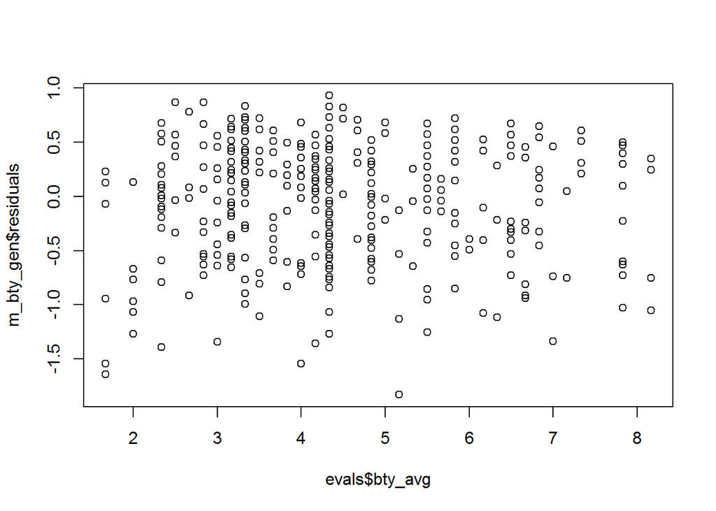

```r
#diagnostic
plot(m_bty_gen$residuals~evals$bty_avg)
```

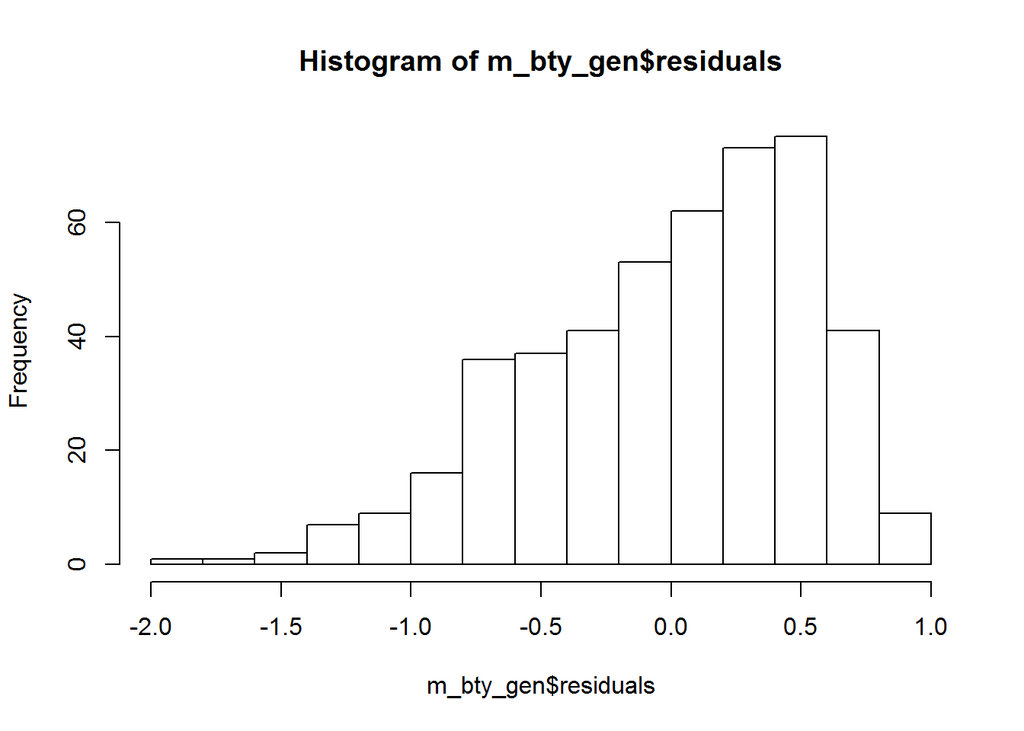

```r
hist(m_bty_gen$residuals)
```

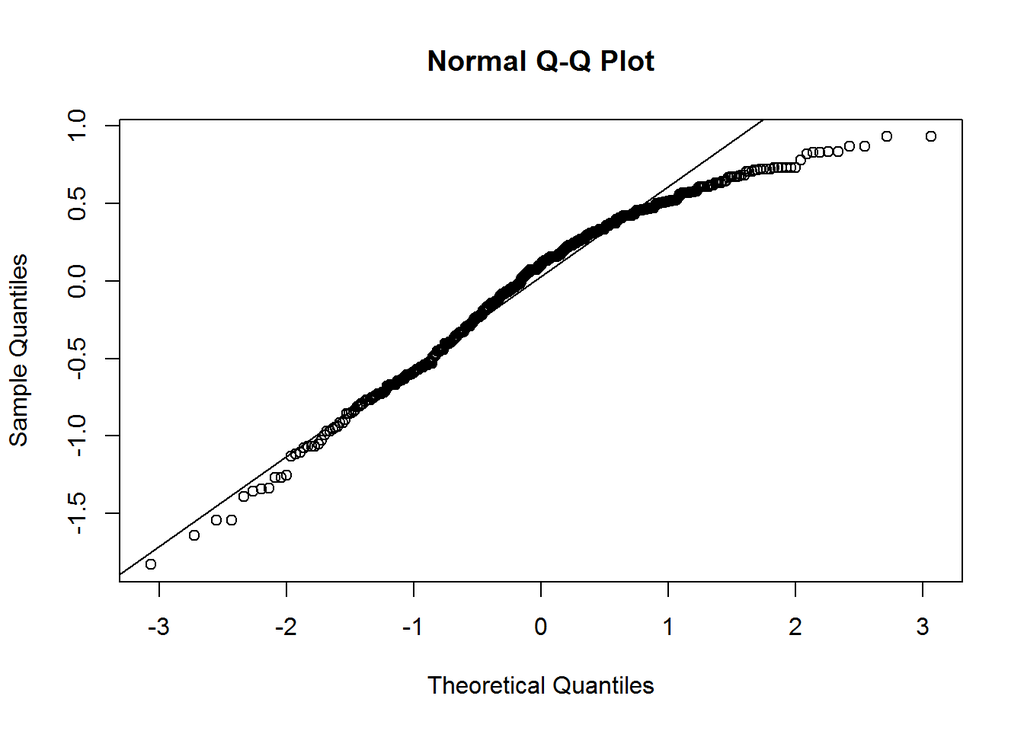

```r
qqnorm(m_bty_gen$residuals)
qqline(m_bty_gen$residuals)
```

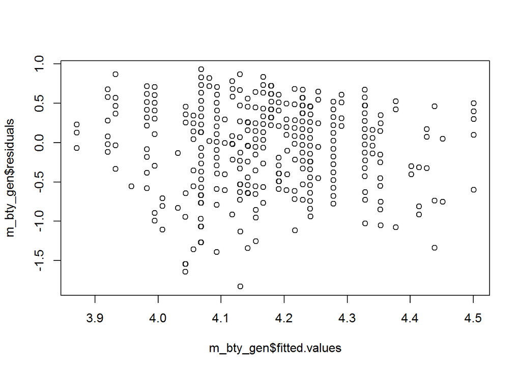

```r
plot(m_bty_gen$residuals~m_bty_gen$fitted.values)
```

P-values and parameter estimates should only be trusted if the conditions for the regression are reasonable. Using diagnostic plots, we can conclude that the conditions for this model are reasonable.

1. True
2. False

answer: a

For two professors (one male and one female) who received the same beauty rating, the male professor is predicted to have the higher course evaluation score than the female.

1. True
2. False

answer: a

```r
m_bty_rank<-lm(score~bty_avg+rank, data = evals)
summary(m_bty_rank)
```

```
##
## Call:
## lm(formula = score ~ bty_avg + rank, data = evals)
##
## Residuals:
##     Min      1Q  Median      3Q     Max
## -1.8713 -0.3642  0.1489  0.4103  0.9525
##
## Coefficients:
##                  Estimate Std. Error t value Pr(>|t|)
## (Intercept)       3.98155    0.09078  43.860  < 2e-16 ***
## bty_avg           0.06783    0.01655   4.098 4.92e-05 ***
## ranktenure track -0.16070    0.07395  -2.173   0.0303 *
## ranktenured      -0.12623    0.06266  -2.014   0.0445 *
## ---
## Signif. codes:  0 '***' 0.001 '**' 0.01 '*' 0.05 '.' 0.1 ' ' 1
##
## Residual standard error: 0.5328 on 459 degrees of freedom
## Multiple R-squared:  0.04652,    Adjusted R-squared:  0.04029
## F-statistic: 7.465 on 3 and 459 DF,  p-value: 6.88e-05
```

```r
anova(m_bty_rank)
```

```
## Analysis of Variance Table
##
## Response: score
##            Df  Sum Sq Mean Sq F value    Pr(>F)
## bty_avg     1   4.786  4.7859 16.8595 4.765e-05 ***
## rank        2   1.571  0.7856  2.7673   0.06388 .
## Residuals 459 130.297  0.2839
## ---
## Signif. codes:  0 '***' 0.001 '**' 0.01 '*' 0.05 '.' 0.1 ' ' 1
```

Which of the following is the correct order of the three levels of rank if we were to order them from lowest predicted course evaluation score to highest predicted course evaluation score?

1. Teaching, Tenure Track, Tenured
2. Tenure track, Tenured
3. Tenure Track, Tenured, Teaching
4. Teaching, Tenured, Tenure Track

answer: c

Full Model

```r
m_full <- lm(score ~ rank + ethnicity + gender + language + age + cls_perc_eval
             + cls_students + cls_level + cls_profs + cls_credits + bty_avg, data = evals)
summary(m_full)
```

```
##
## Call:
## lm(formula = score ~ rank + ethnicity + gender + language + age +
##     cls_perc_eval + cls_students + cls_level + cls_profs + cls_credits +
##     bty_avg, data = evals)
##
## Residuals:
##      Min       1Q   Median       3Q      Max
## -1.84482 -0.31367  0.08559  0.35732  1.10105
##
## Coefficients:
##                         Estimate Std. Error t value Pr(>|t|)
## (Intercept)            3.5305036  0.2408200  14.660  < 2e-16 ***
## ranktenure track      -0.1070121  0.0820250  -1.305 0.192687
## ranktenured           -0.0450371  0.0652185  -0.691 0.490199
## ethnicitynot minority  0.1869649  0.0775329   2.411 0.016290 *
## gendermale             0.1786166  0.0515346   3.466 0.000579 ***
## languagenon-english   -0.1268254  0.1080358  -1.174 0.241048
## age                   -0.0066498  0.0030830  -2.157 0.031542 *
## cls_perc_eval          0.0056996  0.0015514   3.674 0.000268 ***
## cls_students           0.0004455  0.0003585   1.243 0.214596
## cls_levelupper         0.0187105  0.0555833   0.337 0.736560
## cls_profssingle       -0.0085751  0.0513527  -0.167 0.867458
## cls_creditsone credit  0.5087427  0.1170130   4.348  1.7e-05 ***
## bty_avg                0.0612651  0.0166755   3.674 0.000268 ***
## ---
## Signif. codes:  0 '***' 0.001 '**' 0.01 '*' 0.05 '.' 0.1 ' ' 1
##
## Residual standard error: 0.504 on 450 degrees of freedom
## Multiple R-squared:  0.1635, Adjusted R-squared:  0.1412
## F-statistic: 7.331 on 12 and 450 DF,  p-value: 2.406e-12
```

Which of the following is the correct intrepetation of the coefficient associated with the ethnicity variable. Non-minority professors are expected on average to score .

1. 0.19 points lower than minority professors, all else held constant.
2. 0.19 points higher than minority professors, all else held constant.
3. 0.02 points lower than minority professors, all else held constant.
4. 0.02 points higher than minority professors, all else held constant.

answer: b

Dropping rank

```r
m1 <- lm(score ~ ethnicity + gender + language + age + cls_perc_eval
             + cls_students + cls_level + cls_profs + cls_credits + bty_avg, data = evals)
summary(m1)$adj.r.squared
```

```
## [1] 0.1417823
```

Dropping ethnicity

```r
m2 = lm(score ~ rank + gender + language + age + cls_perc_eval +
    cls_students + cls_level + cls_profs + cls_credits + bty_avg, data = evals)
summary(m2)$adj.r.squared
```

```
## [1] 0.1320486
```

Dropping clas_profs

```r
m3 = lm(score ~ rank + gender + language + age + cls_perc_eval +
    cls_students + cls_level + cls_credits + bty_avg + ethnicity, data = evals)
summary(m3)$adj.r.squared
```

```
## [1] 0.1430683
```

Dropping class students

```r
m4 = lm(score ~ rank + gender + language + age + cls_perc_eval +
    ethnicity + cls_level + cls_profs + cls_credits + bty_avg, data = evals)
summary(m4)$adj.r.squared
```

```
## [1] 0.1401804
```

Elimination of which variable from the full model yielded the highest adjusted R-squared?

1. bty_avg
2. cls_profs
3. cls_students
4. rank

answer: cls_profs